# One Health Comparative Genomics of *Escherichia coli* Isolates: Tracking Regional AMR Burden and Emerging Genetic Determinants Across Nine Nations (2018–2022)

CHIJIOKE C. UHEGWU

# 1.0 Introduction

The global escalation of antimicrobial resistance (AMR) represents one of the most complex public health challenges of the 21st century, necessitating a One Health approach that recognizes the interconnectedness of human, animal, and environmental health [1]. This study presents a comparative genomic analysis of AMR in *E. coli* isolates collected across nine countries, aiming to map the distribution and temporal dynamics of resistance determinants within diverse ecological niches. By investigating the genetic signatures of 100 bacterial isolates, this research seeks to identify high-risk resistance genes, such as extended-spectrum beta-lactamase (ESBLs) and carbapenemases, and evaluate their prevalence across clinical and agricultural sectors. Understanding these cross-sectoral and geographic patterns is critical for developing targeted surveillance and stewardship strategies to curb the international spread of multidrug-resistant (MDR) pathogens.

# 2.0 Methodology

This study employed a bioinformatics pipeline integrating high-throughput genomic data. A total of 100 bacterial isolates collected between 2018 and 2022 were retrieved from the NCBI Pathogen Detection Portal, spanning nine countries (Argentina, Brazil, New Zealand, China, Nigeria, France, Germany, United Kingdom, and United States). Initial processing and genomic characterization were conducted in a Linux environment. To identify the presence of antimicrobial resistance determinants, ResFinder was utilized to screen the assembled sequences against a comprehensive database of known AMR genes (Abricate). Following the initial detection phase, the raw output data was imported into the R programming environment. Within R, the data underwent rigorous cleaning and wrangling using the tidyverse suite to standardize gene nomenclature and isolate metadata. Final analysis and visualization were performed to identify temporal trends, geographic clustering, and sector-specific resistance burdens, utilizing hierarchical clustering and longitudinal mapping to illustrate the One Health landscape of AMR.

# 3.0 Results and Discussion

## 3.1 Distribution of Antimicrobial Resistance (AMR) Genes Across One Health Sources

The bar chart in Figure 1 illustrates a significant disparity in the distribution of AMR-positive isolates across different sectors, with human sources contributing the highest number of isolates, followed by chicken and beef. From a One Health perspective, the substantial presence of AMR-positive isolates in poultry (chicken) and livestock (beef) highlights the risks associated with agricultural antibiotic use, often employed for growth promotion or disease prevention. These animal reservoirs serve as critical points of origin for resistant bacteria that can enter the human food chain through contaminated meat products or direct contact, facilitating the cross-species transmission of multidrug-resistant (MDR) pathogens [1].

This overlapping distribution highlights the necessity for integrated genomic surveillance that tracks resistance genes across all three sectors: humans, animals, and the environment. Considering that bacteria and their resistance-conferring genes (such as those on plasmids) move easily between these domains via wastewater, agricultural runoff, and food consumption, a high burden in one sector inevitably impacts the others [2]. Consequently, these findings suggest that mitigating the global AMR threat requires a unified strategy that addresses antibiotic stewardship in human clinics while simultaneously improving biosecurity and manure management in the livestock industry.

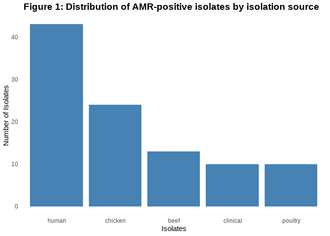

## 3.2 AMR gene burden per isolate by source

Figure 2 highlights the disparity in AMR gene burden across different isolation sources, with human isolates exhibiting the highest and most variable number of resistance genes. The isolates from humans show a median of approximately 8 genes per isolate, with several outliers carrying nearly 20 distinct AMR genes. This high concentration likely reflects the intense selective pressure found in clinical environments, where the frequent use of broad-spectrum antibiotics drives the accumulation of multiple resistance determinants within single bacterial lineages.

In contrast, isolates from chicken and poultry sources show a moderate gene burden, with medians hovering around 3 to 4 genes per isolate. While lower than the human burden, the presence of numerous individual isolates carrying upwards of 10 genes indicates that poultry remains a significant reservoir for MDR bacteria. The wide distribution of data points within the chicken category suggests a diverse range of resistance profiles, possibly linked to varying farming practices and antibiotic stewardship levels across the nine countries included in your study.

The beef and clinical categories show the lowest gene burden, with most isolates carrying only 1 or 2 AMR genes. This minimal burden suggests that, in this specific dataset, these sources have not been subjected to the same level of intensive antimicrobial pressure as human and poultry sectors.

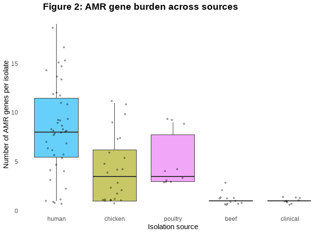

## 3.3 Top AMR genes detected across isolates

Figure 3 illustrates the high frequency and diversity of the most occuring AMR genes detected across the 100 isolates. The figure is dominated by genes conferring resistance to beta-lactam antibiotics, which include penicillins and cephalosporins.

- **blaCTX-M-15_1** is the most frequently detected gene, appearing in over 200 instances across the isolates. This is highly significant as blaCTX-M-15 is a globally dominant variant of extended-spectrum beta-lactamase (ESBL) [3]. Its high frequency suggests widespread resistance to third- and fourth-generation cephalosporins, which are critical for treating severe human infections.
- **blaTEM-1B_1** follows closely as the second most common gene. While often conferring narrower resistance (e.g., to ampicillin), its high prevalence in the isolates highlights its role as a fundamental building block of resistance in Gram-negative bacteria like *E. coli*.
- **blaNDM-5_1** ranks third, which is particularly concerning from a clinical perspective. This gene encodes a carbapenemase, providing resistance to carbapenems, which are “last-resort” antibiotics [4]. Its presence in a high frequency indicates a significant risk of “untreatable” infections moving through the One Health chain.

- **Efflux and Housekeeping Resistance:** The mdf(A)_1 gene, a multidrug efflux pump, is ubiquitous in these isolates. Its role in pumping out various toxic compounds makes it a common feature in both clinical and environmental bacterial genomes.
- **Tetracycline and Sulfonamide Resistance:** Genes like tet(A)_6 and sul2_2 appear with high frequency. These are classic examples of resistance linked to long-term antibiotic use in both human medicine and agriculture (e.g., in poultry and livestock). Their frequent detection underscores the ongoing exchange of genetic material between the environment and food-producing animals.

The presence of multiple high-risk genes in the same dataset suggests that many of these 100 isolates are MDR. Since many of these genes are carried on mobile genetic elements like plasmids [3, 4], they can easily jump between different bacterial species and across geographic borders. This interconnectedness emphasizes that a high frequency of blaNDM-5 or blaCTX-M-15 in one sector, directly threatens the efficacy of antibiotics in human clinics globally.

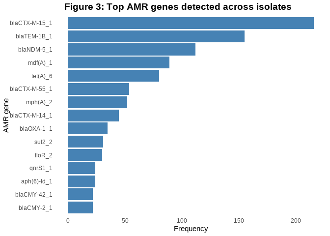

## 3.4 Drug class distribution by isolation source

Figure 4 illustrates a critical disparity in antimicrobial class distribution across One Health sectors, with Beta-lactams emerging as the dominant drug class in both human and chicken isolates. In the isolates retrieved from humans, the count of Beta-lactam resistance exceeds 500, which is significantly higher than all other categories. This trend is also seen in the chicken sector, where Beta-lactams are also the most frequent, though at a lower scale (reaching nearly 110). The high prevalence in these two sectors highlights a significant overlapping resistance profile, likely driven by the widespread clinical and agricultural use of penicillins and cephalosporins.

Beyond Beta-lactams, the sectors exhibit distinct secondary resistance signatures. Human isolates show a substantial burden in the “Other” category (over 200 counts), reflecting a complex multidrug-resistant environment. In contrast, the poultry and chicken sectors demonstrate a more diverse spread across classes like Phenicols, Tetracyclines, and Fluoroquinolones. Notably, the poultry sector shows a high count for Phenicols (near 18), a class often used in veterinary medicine, which appears relatively negligible in the human sector. This distinction highlights sector-specific selective pressures, where agricultural practices introduce unique resistance fingerprints not as commonly seen in human clinical data.

The smaller categories, such as beef and clinical, are dominated by “Unclassified” resistance mechanisms, with beef also showing a presence of Tetracyclines. While the counts in these sectors are lower overall, the “Unclassified” dominance suggests the presence of emerging or less-characterized resistance genes that warrant further investigation.

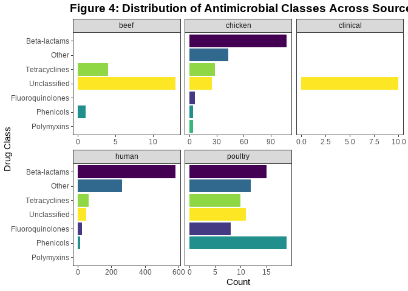

## 3.5 Geographic Patterns of Antimicrobial Resistance

Figure 5 provides a detailed geographic breakdown of antimicrobial class dominance, revealing distinct regional signatures of resistance across the nine countries. China and Nigeria stand out as the most heavily burdened regions, exhibiting a high count and broad diversity of resistance classes. In Nigeria, Beta-lactams are the most prevalent, closely followed by Fluoroquinolones and Tetracyclines, indicating multi-drug resistance that is likely driven by diverse selective pressures. China shows a similarly high burden across nearly all classes, with Phenicols and Tetracyclines reaching high counts (around 15), reflecting the intense antimicrobial use typical of regions with large-scale industrial agriculture and dense human populations [5].

In contrast, Western nations like the United Kingdom, USA, and Germany display more specialized resistance profiles. The USA and UK show a notable presence of Beta-lactams and Tetracyclines, but at lower absolute counts compared to Nigeria or China, suggesting potentially different stewardship levels or a narrower range of circulating MDR clones. Interestingly, Germany and France show a relatively balanced distribution across Beta-lactams, Fluoroquinolones, and Tetracyclines, while Germany uniquely displays a presence of Polymyxin resistance, a critical “last-resort” antibiotic class. This regional variation highlights how local antibiotic consumption patterns in both clinical and veterinary sectors directly shape the genomic AMR profile of each country.

Regions such as Argentina, Brazil, and New Zealand appear dominated by “Unclassified” resistance mechanisms in this specific isolate set. While their documented counts for specific drug classes are lower, the high proportion of Unclassified and Other categories suggests that these regions may harbor emerging or less-common resistance determinants that are not captured by standard classification panels.

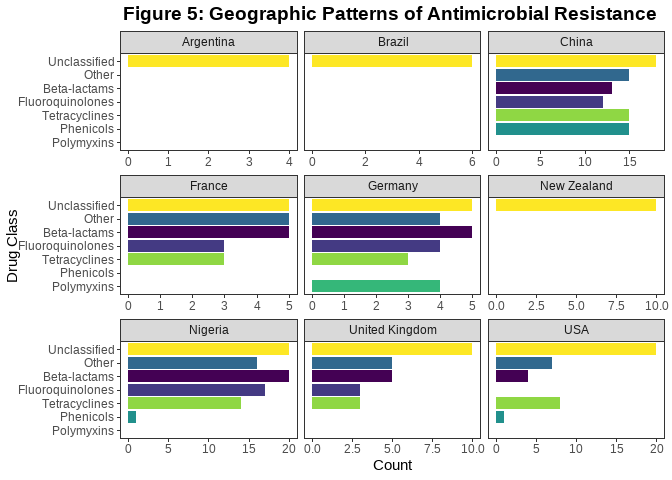

## 3.6 Heatmap of resistance classes by country

Figure 6 provides a comprehensive hierarchical clustering analysis, visualizing the MDR similarities across the nine countries and seven antibiotic classes. The dendrograms and standardized color scale (Z-scores from -2 to 2) reveal two primary clusters of countries based on their resistance fingerprints.

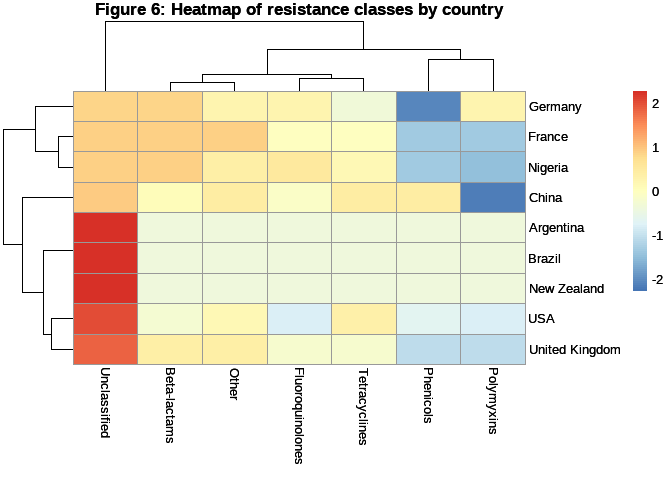

## 3.7 Heatmap of resistance genes by country

Figure 7 provides a high-resolution hierarchical clustering analysis of specific AMR genes across five key countries, revealing how particular molecular determinants drive the regional resistance profiles previously observed.

- **High-Risk Carbapenemase and Beta-Lactamase Signatures:** The heatmap identifies China and Germany as major hotspots for critical beta-lactamase genes, though their genetic drivers differ significantly. China shows a high positive correlation with blaNDM-5_1, a high-risk carbapenemase gene that confers resistance to “last-resort” carbapenem antibiotics. This finding is particularly concerning as blaNDM-5 is known for its high carbapenemase activity and rapid dissemination via IncX3 plasmids [4]. In contrast, Germany displays a dominant signature for blaTEM-1B_1, a common but foundational resistance gene against penicillins. This disparity suggests that while both nations face high beta-lactam pressure, China’s profile is skewed toward newer, more potent carbapenem resistance, whereas Germany’s is anchored in widespread, established ESBL mechanisms.
- **Dominant ESBL and Efflux Drivers in the USA and Nigeria:** A separate cluster identifies USA, Nigeria, and France as being primarily driven by the blaCTX-M-15_1 and mdf(A)_1 genes.Nigeria and France exhibit strong positive correlations with blaCTX-M-15_1, the globally dominant ESBL variant. Its prevalence in these regions highlight a shared risk of treatment failure for common infections, as this gene effectively hydrolyzes third-generation cephalosporins [6]. The USA shows a unique and intense signature for mdf(A)_1, a multi-drug efflux pump. This gene’s high intensity in the US suggests that resistance in this region may be heavily supplemented by non-specific efflux mechanisms that can pump out a wide variety of structurally unrelated toxic compounds, including disinfectants and various antibiotic classes.

The clustering of tet(A)_6 and mph(A)_2 across several regions, particularly showing moderate intensity in China and Nigeria, reflects the ongoing selective pressure from tetracyclines and macrolides—classes heavily used in both human medicine and animal agriculture. The co-occurrence of these “housekeeping” resistance genes with high-risk clinical determinants like blaNDM-5 or blaCTX-M-15 indicates that many of these isolates are likely MDR. From a One Health perspective, this map confirms that regional AMR “personalities” are shaped by a mix of globally successful clones (like those carrying blaCTX-M-15) and locally intensified threats (like blaNDM-5 in China), all of which can easily traverse the human-animal-environment interface.

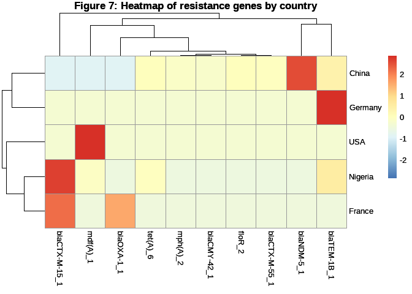

## 3.8 Temporal Trends of Dominant Antimicrobial Resistance Genes (2018–2022)

Figure 8 presents the temporal dynamics of the five most prevalent AMR genes from 2018 to 2022. Notably, it was observed that blaCTX-M-15_1 exponentially increased, rising from approximately 50 detections in 2018 to over 150 by 2020. As a dominant ESBL, its rapid escalation suggests an intensification of selective pressures or the successful clonal expansion of MDR lineages within the One Health framework during this period.

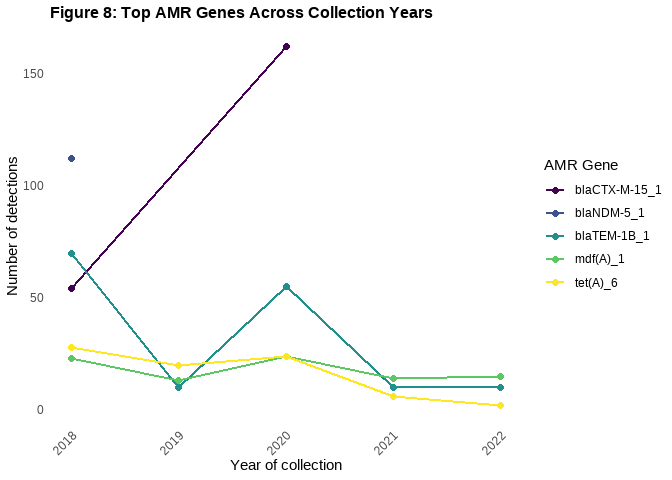

# Conclusion and Recommendations

Findings from this study highlight that AMR is a globalized, interconnected threat where the intensification of resistance in one sector; particularly human, clinical, and poultry production; directly impacts the others. To mitigate this escalating threat, integrated One Health genomic surveillance must be prioritized, focusing on cross-sectoral monitoring of emerging “Unclassified” genes in currently low-burden regions, targeted stewardship in poultry and human clinical sectors to curb the expansion of ESBL and carbapenemase genes, and global collaboration to track the intercontinental movement of high-risk clones like blaCTX-M-15_1.

# References

[1] Lyimo, B., & Sonola, V. (2025). Antimicrobial resistance gene distribution and population structure of escherichia coli isolated from humans, livestock, and the environment: Insights from a one health approach. medRxiv, 2025-04.

[2] Al-Khalaifah, H., Rahman, M. H., Al-Surrayai, T., Al-Dhumair, A., & Al-Hasan, M. (2025). A One-Health perspective of antimicrobial resistance (AMR): Human, animals and environmental health. Life, 15(10), 1598.

[3] Mazumder, R., Abdullah, A., Ahmed, D., & Hussain, A. (2020). High prevalence of Bla CTX-M-15 gene among extended-spectrum β-lactamase-producing Escherichia coli isolates causing extraintestinal infections in Bangladesh. Antibiotics, 9(11), 796.

[4] Liao, W., Quan, J., Huang, L., Zhou, M., Zhang, C., Chen, L., … & Zhou, J. (2025). Emergence of a clinical carbapenem-resistant Escherichia coli co-harboring blandm-5 and mcr-1.1 on the same plasmid. International Journal of Antimicrobial Agents, 66(1), 107495.

[5] Yang, L., Shen, Y., Jiang, J., Wang, X., Shao, D., Lam, M. M., … & Shen, Z. (2022). Distinct increase in antimicrobial resistance genes among Escherichia coli during 50 years of antimicrobial use in livestock production in China. Nature Food, 3(3), 197-205.

[6] Malesa, R., Pierneef, R., Magwedere, K., Mafuna, T., & Matle, I. Shifting Genomes, Rising Threats: Adaptive Evolution and Antimicrobial Resistance of E. coli ST10 across African Ecologies. Rising Threats: Adaptive Evolution and Antimicrobial Resistance of E. coli ST10 across African Ecologies.